# Prediction Assignment

Parth Agnihotri

6 August 2017

## Overview

This course project is to predict the class of exercise the individual was performing using use machine learning algorithms. Data for the project is based on devices such as Jawbone Up, Nike FuelBand, and Fitbit, using which now it is possible to collect a large amount of data about personal activity relatively inexpensively.

Variable “classe” classifies the correct and incorrect outcomes of A, B, C, D, and E categories.

1. Class A - exactly according to the specification
2. Class B - throwing the elbows to the front
3. Class C - lifting the dumbbell only halfway
4. Class D - lowering the dumbbell only halfway
5. Class E - throwing the hips to the front

Analysis for the project will identify the best model (with highest accuracy) and use it to predict “classe” variable in the test data.

## Data Loading and Cleaup

Data for this project is available on following locations:

- Training data: https://d396qusza40orc.cloudfront.net/predmachlearn/pml-training.csv
- Test data: https://d396qusza40orc.cloudfront.net/predmachlearn/pml-testing.csv

```r
# Download Training and Testing data
trainingData <- read.csv(text = getURL("https://d396qusza40orc.cloudfront.net/predmachlearn/pml-training.csv"))
testingData <- read.csv(text = getURL("https://d396qusza40orc.cloudfront.net/predmachlearn/pml-testing.csv"))

dim(trainingData)
```

```
## [1] 19622   160
```

```r
dim(testingData)
```

```
## [1]  20 160
```

```r
# Identify and remove NA columns. Also remove columns which has user details
# as these columns are not useful as predictors.
cols <- names(testingData[,colSums(is.na(testingData)) == 0])[8:59]
trainingData <- trainingData[,c(cols,"classe")]
testingData <- testingData[,c(cols,"problem_id")]
dim(trainingData)
```

```
## [1] 19622    53
```

```r
dim(testingData)
```

```
## [1] 20 53
```

## Partition Data into Training and Testing Sets

70 % of the data is used as Training Set and rest 30 % is used as Test Set.

```r
set.seed(123)
inTrain <- createDataPartition(trainingData$classe, p=0.7, list=FALSE)
training <- trainingData[inTrain,]
testing <- trainingData[-inTrain,]
dim(training)
```

```
## [1] 13737    53
```

```r
dim(testing)
```

```
## [1] 5885   53
```

## Prediction Models

For analysis, this report has built following three models which were discussed in the “Practical Machine Learning” class.

1. Classification Tree
2. Random Forests
3. Generalized Boosted Model (GBM)

### Classification Tree

```r
# Cross-validation at 5-fold
fitControl <- trainControl(method="cv", number=5, allowParallel=T)
# Train model
treeModel <- train(classe~.,data=training, method="rpart",trControl=fitControl, tuneLength = 10)

# Predict by applying model to testing data
predictTree <- predict(treeModel, newdata=testing)
treeConfMatrix <- confusionMatrix(predictTree, testing$classe)
treeConfMatrix
```

```
## Confusion Matrix and Statistics
##
##           Reference
## Prediction    A    B    C    D    E
##          A 1424  184   52   56   25
##          B   26  598   42   46   25
##          C   34  151  719   93  104
##          D  167  104  191  663  134
##          E   23  102   22  106  794
##
## Overall Statistics
##
##                Accuracy : 0.7133
##                  95% CI : (0.7016, 0.7249)
##     No Information Rate : 0.2845
##     P-Value [Acc > NIR] : < 2.2e-16
##
##                   Kappa : 0.6377
##  Mcnemar's Test P-Value : < 2.2e-16
##
## Statistics by Class:
##
##                      Class: A Class: B Class: C Class: D Class: E
## Sensitivity            0.8507   0.5250   0.7008   0.6878   0.7338
## Specificity            0.9247   0.9707   0.9214   0.8789   0.9473
## Pos Pred Value         0.8179   0.8114   0.6530   0.5266   0.7584
## Neg Pred Value         0.9397   0.8949   0.9358   0.9349   0.9405
## Prevalence             0.2845   0.1935   0.1743   0.1638   0.1839
## Detection Rate         0.2420   0.1016   0.1222   0.1127   0.1349
## Detection Prevalence   0.2958   0.1252   0.1871   0.2139   0.1779
## Balanced Accuracy      0.8877   0.7479   0.8111   0.7833   0.8406
```

Accuracy for the model is 0.7133.

## Random Forests

```r
# Cross-validation at 5-fold
fitControl <- trainControl(method="cv", number=5, allowParallel=T)
# Train model
rfModel <- train(classe~.,data=training, method="rf", trControl=fitControl, verbose=F)

# Predict by applying model to testing data
predictRF <- predict(rfModel, newdata=testing)
rfConfMatrix <- confusionMatrix(predictRF, testing$classe)
rfConfMatrix
```

```
## Confusion Matrix and Statistics
##
##           Reference
## Prediction    A    B    C    D    E
##          A 1673    6    0    0    0
##          B    1 1132    9    0    0
##          C    0    1 1014   19    2
##          D    0    0    3  944    1
##          E    0    0    0    1 1079
##
## Overall Statistics
##
##                Accuracy : 0.9927
##                  95% CI : (0.9902, 0.9947)
##     No Information Rate : 0.2845
##     P-Value [Acc > NIR] : < 2.2e-16
##
##                   Kappa : 0.9908
##  Mcnemar's Test P-Value : NA
##
## Statistics by Class:
##
##                      Class: A Class: B Class: C Class: D Class: E
## Sensitivity            0.9994   0.9939   0.9883   0.9793   0.9972
## Specificity            0.9986   0.9979   0.9955   0.9992   0.9998
## Pos Pred Value         0.9964   0.9912   0.9788   0.9958   0.9991
## Neg Pred Value         0.9998   0.9985   0.9975   0.9959   0.9994
## Prevalence             0.2845   0.1935   0.1743   0.1638   0.1839
## Detection Rate         0.2843   0.1924   0.1723   0.1604   0.1833
## Detection Prevalence   0.2853   0.1941   0.1760   0.1611   0.1835
## Balanced Accuracy      0.9990   0.9959   0.9919   0.9892   0.9985
```

Accuracy for the model is 0.9927.

### Generalized Boosted Model (GBM)

```r
# Cross-validation at 5-fold
fitControl <- trainControl(method="cv", number=5, allowParallel=T)
# Train model
gbmModel <- train(classe~.,data=training, method="gbm",trControl=fitControl, verbose=F)

# Predict by applying model to testing data
predictGBM <- predict(gbmModel, newdata=testing)
gbmConfMatrix <- confusionMatrix(predictGBM, testing$classe)
gbmConfMatrix
```

```
## Confusion Matrix and Statistics
##
##           Reference
## Prediction    A    B    C    D    E
##          A 1641   58    0    1    6
##          B   22 1053   37    1    5
##          C    6   27  976   38    6
##          D    4    0   13  919   14
##          E    1    1    0    5 1051
##
## Overall Statistics
##
##                Accuracy : 0.9584
##                  95% CI : (0.9529, 0.9633)
##     No Information Rate : 0.2845
##     P-Value [Acc > NIR] : < 2.2e-16
##
##                   Kappa : 0.9473
##  Mcnemar's Test P-Value : 2.753e-08
##
## Statistics by Class:
##
##                      Class: A Class: B Class: C Class: D Class: E
## Sensitivity            0.9803   0.9245   0.9513   0.9533   0.9713
## Specificity            0.9846   0.9863   0.9842   0.9937   0.9985
## Pos Pred Value         0.9619   0.9419   0.9269   0.9674   0.9934
## Neg Pred Value         0.9921   0.9820   0.9897   0.9909   0.9936
## Prevalence             0.2845   0.1935   0.1743   0.1638   0.1839
## Detection Rate         0.2788   0.1789   0.1658   0.1562   0.1786
## Detection Prevalence   0.2899   0.1900   0.1789   0.1614   0.1798
## Balanced Accuracy      0.9824   0.9554   0.9677   0.9735   0.9849
```

Accuracy for the model is 0.9584.

## Conclusion

Based on the previous section, it is clear that the Random Forests model is best among three models with accuracy of 0.9927.

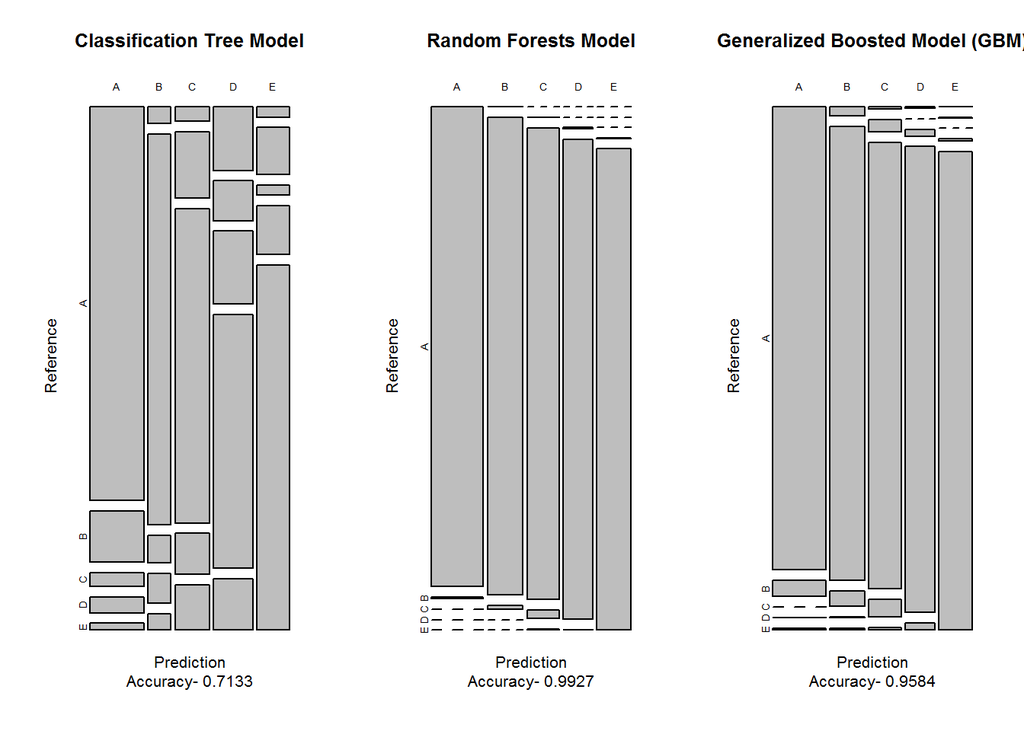

```r
par(mfrow=c(1,3))

plot(treeConfMatrix$table,
     main="Classification Tree Model",
     sub=paste("Accuracy-", round(treeConfMatrix$overall['Accuracy'],4)))

plot(rfConfMatrix$table,
     main="Random Forests Model",
     sub=paste("Accuracy-", round(rfConfMatrix$overall['Accuracy'],4)))

plot(gbmConfMatrix$table,
     main="Generalized Boosted Model (GBM)",
     sub=paste("Accuracy-", round(gbmConfMatrix$overall['Accuracy'],4)))
```

## Applying best model to test data

```r
# Predict value of "classe" variable based on testing data
predictRFTestData <- predict(rfModel, newdata=testingData)
predictRFTestData
```

```
##  [1] B A B A A E D B A A B C B A E E A B B B
## Levels: A B C D E
```

## Appendix

```r
# Classification Tree Model
treeModel$finalModel
```

```
## n= 13737
##
## node), split, n, loss, yval, (yprob)
##       * denotes terminal node
##
##    1) root 13737 9831 A (0.28 0.19 0.17 0.16 0.18)
##      2) roll_belt< 130.5 12580 8681 A (0.31 0.21 0.19 0.18 0.11)
##        4) pitch_forearm< -26.45 1238   45 A (0.96 0.036 0 0 0) *
##        5) pitch_forearm>=-26.45 11342 8636 A (0.24 0.23 0.21 0.2 0.12)
##         10) yaw_belt>=169.5 550   56 A (0.9 0.044 0 0.049 0.0091) *
##         11) yaw_belt< 169.5 10792 8203 B (0.2 0.24 0.22 0.21 0.13)
##           22) magnet_dumbbell_z< -87.5 1420  615 A (0.57 0.28 0.051 0.075 0.025)
##             44) magnet_dumbbell_y>=-565.5 1084  282 A (0.74 0.2 0.0092 0.03 0.025) *
##             45) magnet_dumbbell_y< -565.5 336  148 B (0.0089 0.56 0.18 0.22 0.027) *
##           23) magnet_dumbbell_z>=-87.5 9372 7048 C (0.15 0.23 0.25 0.23 0.14)
##             46) pitch_belt< -42.95 576   96 B (0.014 0.83 0.092 0.033 0.028) *
##             47) pitch_belt>=-42.95 8796 6525 C (0.16 0.19 0.26 0.24 0.15)
##               94) magnet_dumbbell_x>=-445.5 3783 2642 B (0.17 0.3 0.097 0.24 0.19)
##                188) roll_belt< 117.5 2357 1340 B (0.17 0.43 0.025 0.13 0.24)
##                  376) magnet_dumbbell_z< 22.5 581   67 B (0.086 0.88 0 0.014 0.015) *
##                  377) magnet_dumbbell_z>=22.5 1776 1209 E (0.19 0.28 0.033 0.17 0.32)
##                    754) total_accel_dumbbell< 5.5 373   85 A (0.77 0.13 0.021 0.078 0.0027) *
##                    755) total_accel_dumbbell>=5.5 1403  837 E (0.038 0.33 0.036 0.2 0.4)
##                     1510) roll_dumbbell< 39.20537 275   37 B (0.025 0.87 0.0036 0.044 0.062) *
##                     1511) roll_dumbbell>=39.20537 1128  579 E (0.042 0.19 0.044 0.23 0.49) *
##                189) roll_belt>=117.5 1426  830 D (0.18 0.087 0.22 0.42 0.097)
##                  378) roll_belt>=122.5 521  280 A (0.46 0.1 0.17 0.012 0.25)
##                    756) yaw_belt< 4.235 370  129 A (0.65 0.14 0.18 0.016 0.0081) *
##                    757) yaw_belt>=4.235 151   23 E (0 0 0.15 0 0.85) *
##                  379) roll_belt< 122.5 905  315 D (0.02 0.078 0.24 0.65 0.0077) *
##               95) magnet_dumbbell_x< -445.5 5013 3110 C (0.15 0.11 0.38 0.24 0.12)
##                190) roll_dumbbell< -61.80313 1171  367 C (0.037 0.16 0.69 0.045 0.076) *
##                191) roll_dumbbell>=-61.80313 3842 2704 D (0.18 0.1 0.29 0.3 0.13)
##                  382) magnet_dumbbell_z< 23.5 1329  753 A (0.43 0.12 0.048 0.3 0.1)
##                    764) accel_dumbbell_x< -47.5 395   57 A (0.86 0.028 0.03 0.051 0.035) *
##                    765) accel_dumbbell_x>=-47.5 934  561 D (0.25 0.16 0.056 0.4 0.13) *
##                  383) magnet_dumbbell_z>=23.5 2513 1478 C (0.051 0.089 0.41 0.3 0.15)
##                    766) roll_belt>=125.5 391   53 C (0.087 0.033 0.86 0.015 0) *
##                    767) roll_belt< 125.5 2122 1383 D (0.045 0.099 0.33 0.35 0.18)
##                     1534) yaw_belt< -87.65 1039  517 C (0.0029 0.18 0.5 0.13 0.19) *
##                     1535) yaw_belt>=-87.65 1083  475 D (0.085 0.027 0.16 0.56 0.17) *
##      3) roll_belt>=130.5 1157    7 E (0.0061 0 0 0 0.99) *
```

```r
# Random Forest Model
rfModel$finalModel
```

```
##
## Call:
##  randomForest(x = x, y = y, mtry = param$mtry, verbose = ..1)
##                Type of random forest: classification
##                      Number of trees: 500
## No. of variables tried at each split: 27
##
##         OOB estimate of  error rate: 0.67%
## Confusion matrix:
##      A    B    C    D    E class.error
## A 3901    3    1    0    1 0.001280082
## B   19 2632    6    1    0 0.009781791
## C    0   15 2374    7    0 0.009181970
## D    0    0   28 2223    1 0.012877442
## E    0    1    4    5 2515 0.003960396
```

```r
# GBM Model
gbmModel$finalModel
```

```
## A gradient boosted model with multinomial loss function.
## 150 iterations were performed.
## There were 52 predictors of which 42 had non-zero influence.
```